# Main fit function

Umut Caglar

2017-04-03

# Main fit function

This is the wrapper that puts everything together; the input is raw data output is sigmoidal & double sigmoidal fits with `sicegar::parameterCalculation()`, and results for classification. All other parameters can be arranged from this function; but without touch they are all arranged to default settings

To calculate the fits and generate the figures, we will go backwards and firstly generate some data to analize. To add some randomness to the input data I will use some noise. The input of all package must be in the form of a data frame with at least 2 columns time and intensity.

We will generate data for both sigmoidal and double sigmoidal

Generate data for sigmoidal

```r
time=seq(3,24,0.5)

#simulate intensity data and add noise
noise_parameter=0.1
intensity_noise=stats::runif(n = length(time),min = 0,max = 1)*noise_parameter
intensity=sicegar::sigmoidalFitFormula(time, maximum=4, slopeParam=1, midPoint=8)
intensity=intensity+intensity_noise

dataInputSigmoidal=data.frame(intensity=intensity,time=time)
```

Generate data for double - sigmoidal

```r
noise_parameter=0.2
intensity_noise=runif(n = length(time),min = 0,max = 1)*noise_parameter
intensity = sicegar::doublesigmoidalFitFormula(time,
                                    finalAsymptoteIntensityRatio=.3,
                                    maximum=4,
                                    slope1Param=1,
                                    midPoint1Param=7,
                                    slope2Param=1,
                                    midPointDistanceParam=8)
intensity=intensity+intensity_noise
dataInputDoubleSigmoidal=data.frame(intensity=intensity,time=time)
```

## Apply the main function to obtain all results

```r
fitObj_sm <- fitFunction(dataInput = dataInputSigmoidal)
fitObj_dsm <- fitFunction(dataInput = dataInputDoubleSigmoidal)
```

### The results of the sigmoidal fit

The results of sigmoidal fit composes of four components

- `$normalizedInput`: Normalized dataset with normalization parameters in order to generate the raw dataset from normalized one.
- `$sigmoidalModel`: The parameters for sigmoidal fit.
- `$doubleSigmoidalModel`: The parameters for double sigmoidal fit.
- `$outputCluster`: The two fits compete with eachother and the algorithm decides best model that represents the data. The parameters of competation is in the outputCluster.

```r
# Normalized data generated by a sigmoidal model
print(fitObj_sm$normalizedInput)
```

```
## $timeIntensityData
##         time   intensity
## 1  0.1250000 0.000000000
## 2  0.1458333 0.002079141
## 3  0.1666667 0.002811145
## 4  0.1875000 0.004563081
## 5  0.2083333 0.026984704
## 6  0.2291667 0.052748267
## 7  0.2500000 0.100393124
## 8  0.2708333 0.180674603
## 9  0.2916667 0.249881438
## 10 0.3125000 0.373202220
## 11 0.3333333 0.476998349
## 12 0.3541667 0.608299049
## 13 0.3750000 0.714144681
```

[output cut: 37 more lines]

```r
# Parameters of sigmoidal fit for data generated by a sigmoidal model. For details look at "sigmoidal_vignette" and "parameterCalculation_vignette".
print(t(fitObj_sm$sigmoidalModel))
```

```
##                                      [,1]
## maximum_N_Estimate                   "0.9892762"
## maximum_Std_Error                    "0.00172638"
## maximum_t_value                      "573.035"
## maximum_Pr_t                         "6.473173e-80"
## slopeParam_N_Estimate                "24.91311"
## slopeParam_Std_Error                 "0.3550744"
## slopeParam_t_value                   "70.16306"
## slopeParam_Pr_t                      "1.684368e-43"
## midPoint_N_Estimate                  "0.3352606"
## midPoint_Std_Error                   "0.0006568671"
## midPoint_t_value                     "510.3933"
## midPoint_Pr_t                        "6.635846e-78"
## residual_Sum_of_Squares              "0.003021868"
## log_likelihood                       "144.5919"
## AIC_value                            "-281.1837"
## BIC_value                            "-274.1389"
## isThisaFit                           "TRUE"
## startVector.maximum                  "1.469176"
## startVector.slopeParam               "47.06382"
## startVector.midPoint                 "0.5558083"
## dataScalingParameters.timeRange      "24"
## dataScalingParameters.intensityMin   "0.1065867"
## dataScalingParameters.intensityMax   "4.09696"
## dataScalingParameters.intensityRange "3.990373"
## model                                "sigmoidal"
## additionalParameters                 "TRUE"
## maximum_Estimate                     "4.054168"
## slopeParam_Estimate                  "1.038046"
## midPoint_Estimate                    "8.046253"
## dataInputName                        NA
## betterFit                            "2"
## correctFit                           "20"
## totalFit                             "25"
## maximum_x                            NA
## maximum_y                            "4.054168"
## midPoint_x                           "8.046253"
## midPoint_y                           "2.027084"
## slope                                "1.052103"
## incrementTime                        "3.853393"
## startPoint_x                         "6.119557"
## startPoint_y                         "0"
## reachMaximum_x                       "9.97295"
## reachMaximum_y                       "4.054168"
```

```r
# Parameters of double_sigmoidal fit for data generated by a sigmoidal model. For details look at "double_sigmoidal_vignette" and "parameterCalculation_vignette".
print(t(fitObj_sm$doubleSigmoidalModel))
```

```
##                                          [,1]
## finalAsymptoteIntensityRatio_N_Estimate  "0.9885998"
## finalAsymptoteIntensityRatio_Std_Error   "0.008785912"
## finalAsymptoteIntensityRatio_t_value     "112.521"
## finalAsymptoteIntensityRatio_Pr_t        "1.614902e-48"
## maximum_N_Estimate                       "0.9903424"
## maximum_Std_Error                        "0.001852526"
## maximum_t_value                          "534.5903"
## maximum_Pr_t                             "1.5447e-73"
## slope1Param_N_Estimate                   "24.85167"
## slope1Param_Std_Error                    "0.3549397"
## slope1Param_t_value                      "70.01659"
## slope1Param_Pr_t                         "6.242215e-41"
## midPoint1Param_N_Estimate                "0.3353946"
## midPoint1Param_Std_Error                 "0.0006609755"
## midPoint1Param_t_value                   "507.4236"
## midPoint1Param_Pr_t                      "1.063646e-72"
## slope2Param_N_Estimate                   "180"
## slope2Param_Std_Error                    "1361.004"
## slope2Param_t_value                      "0.1322553"
## slope2Param_Pr_t                         "0.8954989"
## midPointDistanceParam_N_Estimate         "0.625"
## midPointDistanceParam_Std_Error          "0.02689049"
## midPointDistanceParam_t_value            "23.24242"
## midPointDistanceParam_Pr_t               "1.13655e-23"
## residual_Sum_of_Squares                  "0.002782947"
## log_likelihood                           "146.3627"
## AIC_value                                "-278.7254"
## BIC_value                                "-266.397"
## isThisaFit                               "TRUE"
## startVector.finalAsymptoteIntensityRatio "0.3620635"
## startVector.maximum                      "0.8384534"
## startVector.slope1Param                  "47.56341"
## startVector.midPoint1Param               "0.4024245"
## startVector.slope2Param                  "36.33399"
## startVector.midPointDistanceParam        "0.3970594"
## dataScalingParameters.timeRange          "24"
## dataScalingParameters.intensityMin       "0.1065867"
## dataScalingParameters.intensityMax       "4.09696"
## dataScalingParameters.intensityRange     "3.990373"
```

[output cut: 16 more lines]

```
## midPoint2_x                              "23.04947"
## midPoint2_y                              "4.035289"
## slope1                                   "1.050612"
## slope2                                   "-0.0867501"
## finalAsymptoteIntensity                  "4.012156"
## incrementTime                            "3.862913"
## startPoint_x                             "6.11801"
## startPoint_y                             "0"
## reachMaximum_x                           "9.980923"
## reachMaximum_y                           "4.058422"
## decrementTime                            "0.5333325"
## startDeclinePoint_x                      "22.7828"
## startDeclinePoint_y                      "4.058422"
## endDeclinePoint_x                        "23.31614"
## endDeclinePoint_y                        "4.012156"
```

```r
# comparison of sigmoidal and double_sigmoidal models for data generated by a sigmoidal model. Sigmoidal model is the winner. For details of the parameters look at "categorize_vignette"
utils::str(fitObj_sm$outputCluster)
```

```
## List of 40
##  $ test.name                               : logi NA
##  $ dataInputName                           : logi NA
##  $ test.sm_modelCheck                      : logi TRUE
##  $ test.dsm_modelCheck                     : logi TRUE
##  $ test.dataScalingParameters              : logi TRUE
##  $ intensityMaximum                        : num 4.1
##  $ threshold_minimum_for_intensity_maximum : num 0.3
##  $ test.minimum_for_intensity_maximum      : logi TRUE
##  $ intensityRange                          : num 3.99
##  $ threshold_intensity_range               : num 0.1
##  $ test.intensity_range                    : logi TRUE
##  $ test.sigmoidalFit                       : logi TRUE
##  $ test.doublesigmoidalFit                 : logi TRUE
##  $ test.sigmoidalAdditionalParameters      : logi TRUE
```

[output cut: 26 more lines]

```r
# Summary of the results
utils::str(fitObj_sm$summaryVector)
```

```
## List of 12
##  $ dataInputName : logi NA
##  $ decision      : chr "sigmoidal"
##  $ maximum_x     : logi NA
##  $ maximum_y     : num 4.05
##  $ midPoint_x    : num 8.05
##  $ midPoint_y    : num 2.03
##  $ slope         : num 1.05
##  $ incrementTime : num 3.85
##  $ startPoint_x  : num 6.12
##  $ startPoint_y  : num 0
##  $ reachMaximum_x: num 9.97
##  $ reachMaximum_y: num 4.05
```

### The results of the double_sigmoidal fit

```r
# Normalized data generated by a double_sigmoidal model
print(fitObj_dsm$normalizedInput)
```

```
## $timeIntensityData
##         time  intensity
## 1  0.1250000 0.00000000
## 2  0.1458333 0.02150040
## 3  0.1666667 0.04153937
## 4  0.1875000 0.07667150
## 5  0.2083333 0.12246434
## 6  0.2291667 0.17323374
## 7  0.2500000 0.28579963
## 8  0.2708333 0.37836736
## 9  0.2916667 0.48927416
## 10 0.3125000 0.65875400
## 11 0.3333333 0.74046767
## 12 0.3541667 0.86004487
## 13 0.3750000 0.90453940
```

[output cut: 37 more lines]

```r
# Parameters of sigmoidal fit for data generated by a double_sigmoidal model. For details look at "sigmoidal_vignette" and "parameterCalculation_vignette".
print(t(fitObj_dsm$sigmoidalModel))
```

```
##                                      [,1]
## maximum_N_Estimate                   "0.5911094"
## maximum_Std_Error                    "0.04633623"
## maximum_t_value                      "12.75696"
## maximum_Pr_t                         "1.111281e-15"
## slopeParam_N_Estimate                "47.84047"
## slopeParam_Std_Error                 "47.1239"
## slopeParam_t_value                   "1.015206"
## slopeParam_Pr_t                      "0.3161093"
## midPoint_N_Estimate                  "0.2488228"
## midPoint_Std_Error                   "0.02349637"
## midPoint_t_value                     "10.58984"
## midPoint_Pr_t                        "3.604816e-13"
## residual_Sum_of_Squares              "2.823893"
## log_likelihood                       "-2.468056"
## AIC_value                            "12.93611"
## BIC_value                            "19.98091"
## isThisaFit                           "TRUE"
## startVector.maximum                  "1.325411"
## startVector.slopeParam               "107.2864"
## startVector.midPoint                 "0.1971991"
## dataScalingParameters.timeRange      "24"
## dataScalingParameters.intensityMin   "0.1416318"
## dataScalingParameters.intensityMax   "4.093882"
## dataScalingParameters.intensityRange "3.95225"
## model                                "sigmoidal"
## additionalParameters                 "TRUE"
## maximum_Estimate                     "2.477844"
## slopeParam_Estimate                  "1.993353"
## midPoint_Estimate                    "5.971747"
## dataInputName                        NA
## betterFit                            "2"
## correctFit                           "20"
## totalFit                             "29"
## maximum_x                            NA
## maximum_y                            "2.477844"
## midPoint_x                           "5.971747"
## midPoint_y                           "1.238922"
## slope                                "1.234804"
## incrementTime                        "2.006669"
## startPoint_x                         "4.968412"
## startPoint_y                         "0"
## reachMaximum_x                       "6.975082"
## reachMaximum_y                       "2.477844"
```

```r
# Parameters of double_sigmoidal fit for data generated by a double_sigmoidal model. For details look at "double_sigmoidal_vignette" and "parameterCalculation_vignette".
print(t(fitObj_dsm$doubleSigmoidalModel))
```

```
##                                          [,1]
## finalAsymptoteIntensityRatio_N_Estimate  "0.2935536"
## finalAsymptoteIntensityRatio_Std_Error   "0.004875493"
## finalAsymptoteIntensityRatio_t_value     "60.21004"
## finalAsymptoteIntensityRatio_Pr_t        "1.582681e-38"
## maximum_N_Estimate                       "0.9941972"
## maximum_Std_Error                        "0.005805047"
## maximum_t_value                          "171.2643"
## maximum_Pr_t                             "2.958662e-55"
## slope1Param_N_Estimate                   "24.42095"
## slope1Param_Std_Error                    "0.7015857"
## slope1Param_t_value                      "34.80822"
## slope1Param_Pr_t                         "7.061832e-30"
## midPoint1Param_N_Estimate                "0.2923032"
## midPoint1Param_Std_Error                 "0.001495442"
## midPoint1Param_t_value                   "195.4628"
## midPoint1Param_Pr_t                      "2.237123e-57"
## slope2Param_N_Estimate                   "24.61658"
## slope2Param_Std_Error                    "1.057588"
## slope2Param_t_value                      "23.27616"
## slope2Param_Pr_t                         "1.080757e-23"
## midPointDistanceParam_N_Estimate         "0.3337014"
## midPointDistanceParam_Std_Error          "0.003007652"
## midPointDistanceParam_t_value            "110.9508"
## midPointDistanceParam_Pr_t               "2.712175e-48"
## residual_Sum_of_Squares                  "0.00780131"
## log_likelihood                           "124.2009"
## AIC_value                                "-234.4018"
## BIC_value                                "-222.0734"
## isThisaFit                               "TRUE"
## startVector.finalAsymptoteIntensityRatio "0.4859528"
## startVector.maximum                      "0.899552"
## startVector.slope1Param                  "59.77961"
## startVector.midPoint1Param               "0.5416556"
## startVector.slope2Param                  "88.05782"
## startVector.midPointDistanceParam        "0.3474758"
## dataScalingParameters.timeRange          "24"
## dataScalingParameters.intensityMin       "0.1416318"
## dataScalingParameters.intensityMax       "4.093882"
## dataScalingParameters.intensityRange     "3.95225"
```

[output cut: 16 more lines]

```
## midPoint2_x                              "15.08724"
## midPoint2_y                              "2.632994"
## slope1                                   "1.068593"
## slope2                                   "-0.7609189"
## finalAsymptoteIntensity                  "1.195041"
## incrementTime                            "3.809635"
## startPoint_x                             "5.04679"
## startPoint_y                             "0"
## reachMaximum_x                           "8.856424"
## reachMaximum_y                           "4.070948"
## decrementTime                            "3.779517"
## startDeclinePoint_x                      "13.19748"
## startDeclinePoint_y                      "4.070948"
## endDeclinePoint_x                        "16.977"
## endDeclinePoint_y                        "1.195041"
```

```r
# comparison of sigmoidal and double_sigmoidal models for data generated by a double_sigmoidal model. double_sigmoidal model is the winner. For details of the parameters look at "categorize_vignette"
utils::str(fitObj_dsm$outputCluster)
```

```
## List of 40
##  $ test.name                               : logi NA
##  $ dataInputName                           : logi NA
##  $ test.sm_modelCheck                      : logi TRUE
##  $ test.dsm_modelCheck                     : logi TRUE
##  $ test.dataScalingParameters              : logi TRUE
##  $ intensityMaximum                        : num 4.09
##  $ threshold_minimum_for_intensity_maximum : num 0.3
##  $ test.minimum_for_intensity_maximum      : logi TRUE
##  $ intensityRange                          : num 3.95
##  $ threshold_intensity_range               : num 0.1
##  $ test.intensity_range                    : logi TRUE
##  $ test.sigmoidalFit                       : logi TRUE
##  $ test.doublesigmoidalFit                 : logi TRUE
##  $ test.sigmoidalAdditionalParameters      : logi TRUE
```

[output cut: 26 more lines]

```r
# Summary of the results
utils::str(fitObj_dsm$summaryVector)
```

```
## List of 21
##  $ dataInputName          : logi NA
##  $ decision               : chr "double_sigmoidal"
##  $ maximum_x              : num 11
##  $ maximum_y              : num 4.07
##  $ midPoint1_x            : num 6.95
##  $ midPoint1_y            : num 2.04
##  $ midPoint2_x            : num 15.1
##  $ midPoint2_y            : num 2.63
##  $ slope1                 : num 1.07
##  $ slope2                 : num -0.761
##  $ finalAsymptoteIntensity: num 1.2
##  $ incrementTime          : num 3.81
##  $ startPoint_x           : num 5.05
##  $ startPoint_y           : num 0
##  $ reachMaximum_x         : num 8.86
##  $ reachMaximum_y         : num 4.07
##  $ decrementTime          : num 3.78
##  $ startDeclinePoint_x    : num 13.2
##  $ startDeclinePoint_y    : num 4.07
##  $ endDeclinePoint_x      : num 17
##  $ endDeclinePoint_y      : num 1.2
```

## Generate figures

Here are the two datasets that we want to categorize

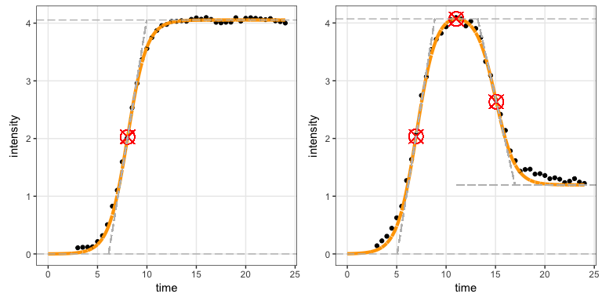

```r
fig_a=sicegar::figureModelCurves(dataInput=fitObj_sm$normalizedInput,
                                  sigmoidalFitVector=fitObj_sm$sigmoidalModel,
                                  showParameterRelatedLines=TRUE)

# Double Sigmoidal Fit with parameter related lines
fig_b=sicegar::figureModelCurves(dataInput=fitObj_dsm$normalizedInput,
                                  doubleSigmoidalFitVector=fitObj_dsm$doubleSigmoidalModel,
                                  showParameterRelatedLines=TRUE)

fig <- cowplot::plot_grid(fig_a, fig_b, ncol = 2)
print(fig)
```